# Análisis de Factores Determinantes en el Rendimiento Escolar

Trabajo de Modelos de Regresión - Grupo 5

Autores/as

Javier Ugena García

Soraya Burgos Modrego

Elba Jares Darriba

Fecha de publicación

23 de marzo de 2026

# 1 Introducción

El objetivo de este trabajo es identificar qué factores (sociales, familiares y académicos) tienen un impacto significativo en la nota final de los estudiantes. Utilizaremos el dataset *Student Performance* de la UCI, que recoge datos de dos asignaturas: Matemáticas y Portugués.

# 2 Contexto del Proyecto y Descripción de los Datos

El objetivo de este análisis es predecir el rendimiento académico de los estudiantes en las asignaturas de Matemáticas y Portugués en dos escuelas portuguesas. Los datos incluyen atributos demográficos, sociales y académicos recogidos mediante informes escolares y cuestionarios.

## 2.1 Diccionario de Variables Principales

Para el desarrollo de los modelos de regresión, es vital entender el significado de las variables clave:

- G1 y G2: Calificaciones del primer y segundo periodo (escala de 0 a 20).
- G3: Calificación final. Es nuestra **variable respuesta** (escala de 0 a 20).
- Medu / Fedu: Nivel educativo de la madre y el padre (0: ninguno, 1: educación primaria, 2: 5º a 9º grado, 3: secundaria o 4: educación superior).
- failures: Número de clases suspendidas anteriormente (n si $1 \leq n < 3$, de lo contrario 4).
- absences: Número de ausencias escolares (de 0 a 93).
- studytime: Tiempo de estudio semanal (1: <2h, 2: 2 a 5h, 3: 5 a 10h, o 4: >10h).

## 2.2 Carga y Estructura de los Dataframes

Cargamos ambos ficheros para verificar que la importación es correcta según los metadatos proporcionados.

**Código**

```r
# Carga de datos
df_mat <- read.csv("datos/student-mat.csv", sep = ";")
df_por <- read.csv("datos/student-por.csv", sep = ";")

# Observamos la dimensión de los datos para confirmar la carga
# El dataset de Matemáticas tiene 395 instancias y 33 atributos
dim(df_mat)
```

```
[1] 395  33
```

**Código**

```r
# El dataset de Portugués tiene 649 instancias y 33 atributos
dim(df_por)
```

```
[1] 649  33
```

**Código**

```r
# Unimos los dataframes para encontrar alumnos comunes. Según la documentación, hay alumnos que aparecen en ambos
df_total <- merge(df_mat, df_por, by=c("school","sex","age","address","famsize","Pstatus","Medu","Fedu","Mjob","Fjob","reason","nursery","internet"))

# Comprobamos cuántos alumnos cursan ambas asignaturas
# El dataset total tiene 382 instancias, lo que indica que hay 382 alumnos que cursan ambas asignaturas
nrow(df_total)
```

```
[1] 382
```

# 3 Preparación de Datos y Análisis Exploratorio (EDA)

## 3.1 Carga de datos y limpieza

Para empezar, cargamos el dataset de Matemáticas. Hemos decidido centrarnos inicialmente en este porque suele presentar una mayor variabilidad en las notas. Observamos que el separador es el punto y coma (`;`).

**Código**

```r
library(tidyverse)
library(corrplot)

# Cargamos el dataset de la carpeta local 'datos'
df_mat <- read.csv("datos/student-mat.csv", sep = ";")

# Verificamos si hay valores nulos para asegurar la calidad del modelo
sum(is.na(df_mat))
```

```
[1] 0
```

Observación: No hay valores nulos en el dataset, por lo que podemos proceder sin imputación de datos. Sin embargo, observamos variables categóricas (como sex, address, Mjob) que deberemos tratar más adelante si queremos incluirlas en la regresión múltiple.

## 3.2 Análisis Exploratorio Visual

Analizamos la distribución de las notas y la relación entre la educación de los padres y el éxito del estudiante.

**Código**

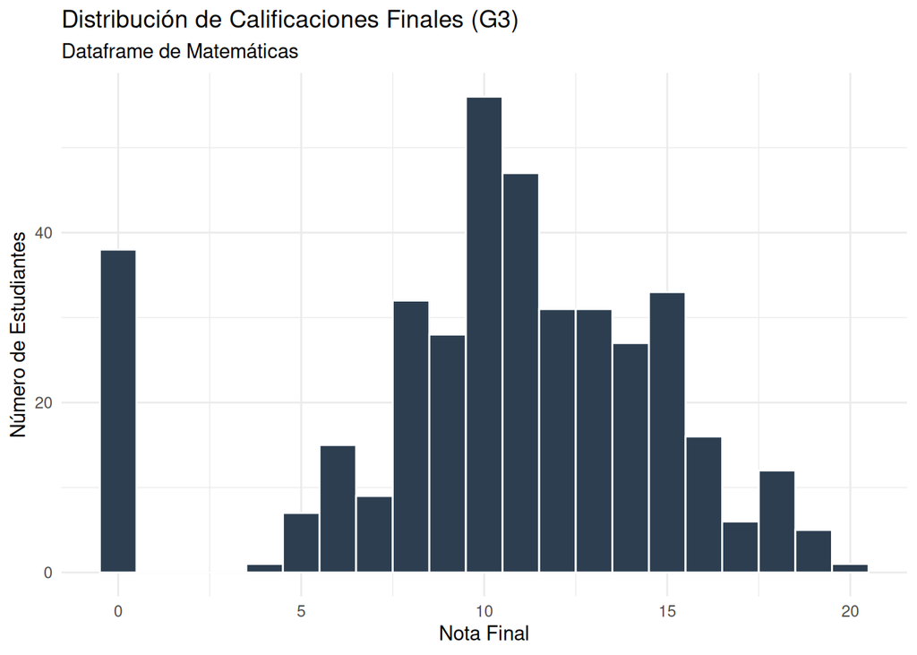

```r
# Histograma de la nota final en matemáticas
ggplot(df_mat, aes(x = G3)) +
  geom_histogram(binwidth = 1, fill = "#2c3e50", color = "white") +
  labs(title = "Distribución de Calificaciones Finales (G3)",
       subtitle = "Dataframe de Matemáticas",
       x = "Nota Final", y = "Número de Estudiantes") +
  theme_minimal()
```

**Código**

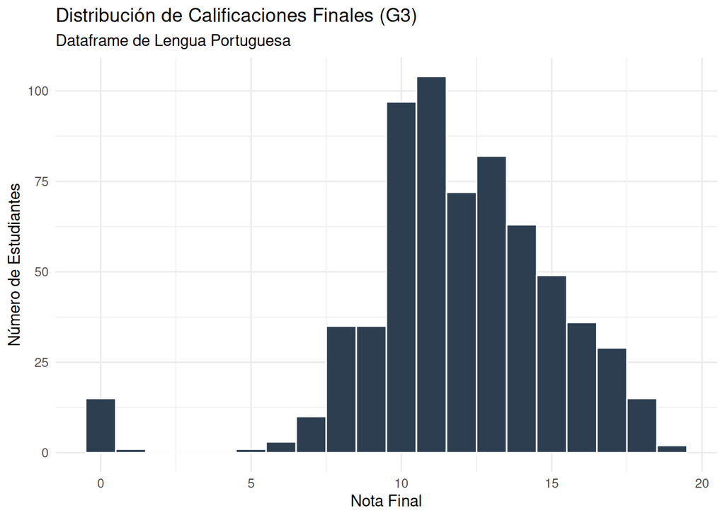

```r
# Histograma de la nota final en lengua portuguesa
ggplot(df_por, aes(x = G3)) +
  geom_histogram(binwidth = 1, fill = "#2c3e50", color = "white") +
  labs(title = "Distribución de Calificaciones Finales (G3)",
       subtitle = "Dataframe de Lengua Portuguesa",
       x = "Nota Final", y = "Número de Estudiantes") +
  theme_minimal()
```

## 3.3 Matriz de Correlación

Para continuar con el modelo, necesitamos identificar qué variables numéricas tienen una relación significativa con la nota final (G3). Para ello, calculamos la matriz de correlación y visualizamos los resultados.

**Código**

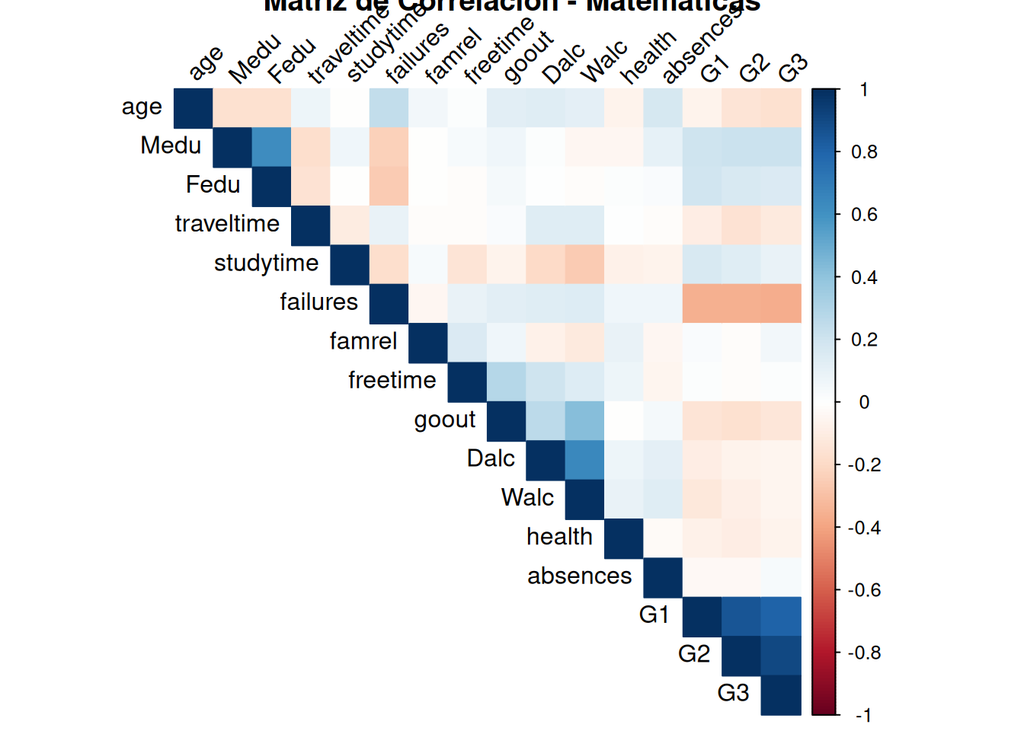

```r
# Seleccionamos solo las variables numéricas para el análisis de correlación

numeric_vars_mat <- df_mat %>%
  select_if(is.numeric)

numeric_vars_por <- df_por %>%
  select_if(is.numeric)

# Calculamos la matriz de correlación

cor_matrix_mat <- cor(numeric_vars_mat)

cor_matrix_por <- cor(numeric_vars_por)

# Visualizamos la matriz de correlación

corrplot(cor_matrix_mat, method = "color", type = "upper", tl.col = "black", tl.srt = 45, title = "Matriz de Correlación - Matemáticas")
```

**Código**

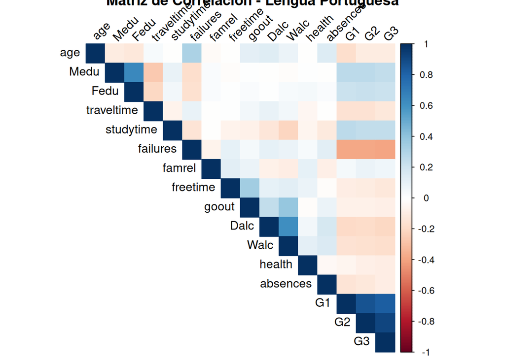

```r
corrplot(cor_matrix_por, method = "color", type = "upper", tl.col = "black", tl.srt = 45, title = "Matriz de Correlación - Lengua Portuguesa")
```